# HOW CAN ADULTS SUFFERING FROM DEPRESSION BE CLUSTERED?

Anne Lösch

[figure not shown]

Photo by [Ethan Sykes](https://unsplash.com/@e_sykes?utm_source=unsplash&utm_medium=referral&utm_content=creditCopyText) on [Unsplash](https://unsplash.com/s/photos/depressed?utm_source=unsplash&utm_medium=referral&utm_content=creditCopyText)

- Introduction
- Research Question
- Data
- Methods
- Results
- Discussion and Recommendations
- References
- Appendix

# Introduction

At least 17 million adults in the US suffer from depression each year.<sup>1</sup> And, according to the NCBI article, Depression: How effective are antidepressants?<sup>2</sup>, only 40 to 60 percent of those with severe depression who take antidepressants notice an improvement in their symptoms. In this project I would like to explore how adults suffering from depression can be clustered. If a clear seperation of clusters can be found, tailored treatments can be created to better help those sufferening from depression. This is a topic of personal interest as my husband suffers from chronic depression.

# Research Question

How can adults suffering from depression be clustered?

# Data

In order to answer this question, I am using data from the 2019 National Health Interview Survey, Sample Adult Interview.<sup>3</sup> The National Health Intervey Survey is a yearly survey meant to 'monitor the health of the United States population.'<sup>4</sup> It is a survey conducted in person throughout the year each year. Populations not included in the survey: individuals with no fixed address, military personnel on active duty, people in long term care facilities, and US citizens living outside the US. Due to this and the fact it is an optional survey, results are not completely representative of the entire US population.

The 2019 survey comes in two forms: an adult interview and a child interview. For the project I chose to use data from the adult interview.

Topics covered in the survey include but is not limited to: demographic data, chronic illnesses, mental health, health insurance coverage, substance use.

```python
df = pd.read_csv('data/adult19.csv')
df.info()
```

```
<class 'pandas.core.frame.DataFrame'>
RangeIndex: 31997 entries, 0 to 31996
Columns: 534 entries, URBRRL to POVRATTC_A
dtypes: float64(369), int64(164), object(1)
memory usage: 130.4+ MB
```

```python
variables_df = pd.read_csv('vars.csv')
variables_df
```

|  | Variable | Question/Description | Category |
| --- | --- | --- | --- |
| 0 | DEPEV_A | Ever had depression | depression |
| 1 | DEPFREQ_A | How often depressed | depression |
| 2 | DEPMED_A | Take medication for depression | depression |
| 3 | DEPLEVEL_A | Level of how depressed | depression |
| 4 | PHQ81_A | How often little interest in things past 2 weeks | depression |
| 5 | PHQ82_A | How often feeling down past 2 weeks | depression |
| 6 | PHQ83_A | How often trouble with sleeping past 2 weeks | depression |
| 7 | PHQ84_A | How often feeling tired past 2 weeks | depression |
| 8 | PHQ85_A | How often undereating or overeating past 2 weeks | depression |
| 9 | PHQ86_A | How often feeling bad about self past 2 weeks | depression |
| 10 | PHQ87_A | How often trouble concentrating past 2 weeks | depression |
| 11 | PHQ88_A | How often moving or speaking slow or fast past... | depression |
| 12 | AGEP_A | Age | demographics |
| 13 | SEX_A | Sex | demographics |
| 14 | MARITAL_A | Marital status | demographics |
| 15 | FAMINCTC_A | Family Income | demographics |
| 16 | EDUC_A | Education | demographics |
| 17 | EMPWRKLSWK_A | Working | demographics |
| 18 | RACEALLP_A | Race | demographics |
| 19 | HISP_A | Ethnicity | demographics |
| 20 | OPD12M_A | Opiod use | substances |
| 21 | SMKNOW_A | Cigarette use | substances |
| 22 | ECIGNOW_A | Ecigarette use | substances |
| 23 | HYPEV_A | Ever been told you have hypertension | chronic_conditions |
| 24 | CHLEV_A | Ever been told you have high cholesterol | chronic_conditions |
| 25 | ASEV_A | Ever been told you have asthma | chronic_conditions |
| 26 | CANEV_A | Ever been told you have cancer | chronic_conditions |
| 27 | DIBEV_A | Ever been told you have diabetes | chronic_conditions |
| 28 | COPDEV_A | Ever been told you have COPD emphysema or chro... | chronic_conditions |

For the project, I decided to choose only the observations in which the person feels depression at least on a weekly basis. According the the American Psychiatric Association, symptoms must last at least two weeks for a diagnosis of depression.<sup>5</sup> This is why I chose only those that feel depression on a weekly basis.

## Checking for null values

Since more than a third of the observations have missing values for variables SMKNOW_A and ECIGNOW_A, I am going to drop the variables having to do with substance use.

# Methods

The algoritms I plan to use to cluster the data are

- Kmeans clustering
- DBSCAN clustering

Hierarchal clustering and Gausian mixture models will not be used as the number of clusters needs to be known in advance. With kmeans, this can be determined using inertia. It would be intersting to explore Hierarchal clustering and Gaussian mixture models in the future.

Silhouette score will be used to evaluate the clustering and determine the best clustering.

I plan to first cluster with only the data with questions regarding depression and then add variables having to do with demographics and chronic conditions

## Subsets of data to be clustered

- Depression data
- Depression data + demographic data
- Depression data + data on chronic conditions
- Depression data + demographic data + data on chronic conditions

## Data preparation

### Encoding variables related to depression

Since all these questions have values which fall into an order I am going to ordinal encode them instead of one hot encode them. To see why look at 'Why not one hot encode the depression variables' in the appendix.

For DEPEV_A: 0 for no, 1 for other and 2 for yes. I was planning on doing -1 for no, 0 for other and 1 for yes but since I plan to use MinMaxScaler before kmeans, it is the same.

For DEPFREQ_A: 1 for daily and 2 for weekly

DEPMED_A is the same as DEPEV_A values 0 for no, 1 for other and 2 for yes.

For DEPLEVEL_A: 0 for other, 1 for a little, 2 for somewhere in between and 3 for a lot.

For PHQ81_A through PHQ88_A: 0 for not at all, 1 for other, 2 for several days, 3 for more than half the days, and 4 for nearly every day.

### Encoding demographic variables

Categorical demographic data, with the exception of education level will be one hot encoded. For race, the two American Indian groups will be combined and the 'other or multiple races' will be combined with other. For eduction levels:

0: never attended/kindergarten only or other 1: Grades 8-11, 12th grade no diploma 2: High school diploma or GED 3: Some college, no degree 4: Associate's degree, either type 5: Bachelor's degree 6: Masters or professional degree 7: Doctoral degree.

A MinMaxScaler will be applied before clustering.

### Encoding chronic conditions

Chronic condition variables will be encoded with 0 for no, 1 for other and 2 for yes

## Performing Clustering

### Depression variables

#### Visualizing the data

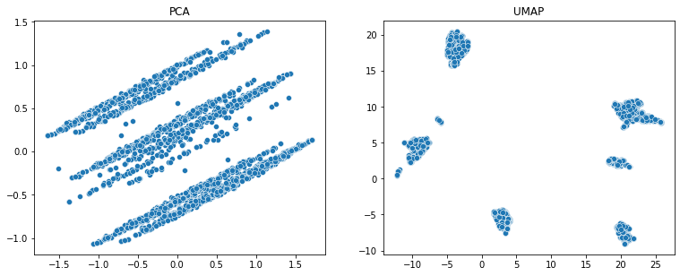

```python
scaler = MinMaxScaler()
X = scaler.fit_transform(depressed_core_df.values)
pca=PCA(n_components=2)
X_2d_pca = pca.fit_transform(X)
umap = UMAP(n_components=2)
X_2d_umap = umap.fit_transform(X)
fig, axs = plt.subplots(1,2,figsize=(12.8,4.8))
sns.scatterplot(x=X_2d_pca[:,0],y=X_2d_pca[:,1], ax=axs[0])
axs[0].set_title('PCA')
sns.scatterplot(x=X_2d_umap[:,0],y=X_2d_umap[:,1], ax=axs[1])
axs[1].set_title('UMAP')
```

From the visualization you can see clusters. However because of loss of information, nothing can be inferred.

#### Kmeans clustering

I'm going to use an inertia plot and the Kneed library to help find the elbow to chose te appropriate number of clusters.

```
The elbow occurs at 11
```

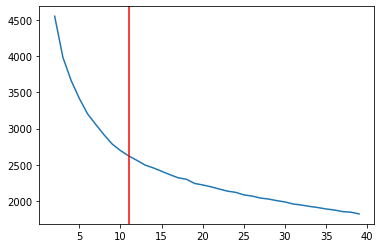

```python
inertia_values = []
for n in range(2,40):
    kmeans = KMeans(n_clusters=n, random_state=625+n)
    kmeans.fit(X)
    inertia_values.append((n,kmeans.inertia_))
results = list(zip(*inertia_values))
kl = KneeLocator(x=results[0],y=results[1],direction='decreasing',curve='convex')
elbow = kl.elbow
print('The elbow occurs at',elbow)

sns.lineplot(x=results[0],y=results[1])
plt.axvline(x=elbow, ymin=0, ymax = max(results[1]), color='red')
```

The curve is mostly smooth, it is hard to determine the elbow. I would guess maybe around 17. According to kneed, the elbow appears at 11. I will use 11 for the number of clusters and come up with the silhouette score

```python
kmeans = KMeans(n_clusters=11, random_state=625)
preds = kmeans.fit_predict(X)
score = silhouette_score(X,preds)
silhouette_scores['data set'].append('depression variables')
silhouette_scores['clustering method'].append('kmeans--auto-11')
silhouette_scores['score'].append(score)
print("The silhouette score for 11 clusters is {}".format(score))
```

```
The silhouette score for 11 clusters is 0.17040533120852125
```

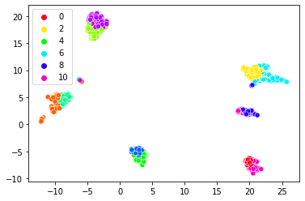

```python
kmeans = KMeans(n_clusters=11, random_state=625)
preds = kmeans.fit_predict(X)
sns.scatterplot(x=X_2d_umap[:,0],y=X_2d_umap[:,1], hue = preds, palette='gist_rainbow')
```

Notice that some clusters do appear to be mixing when viewed two dimensionally.

#### DBSCAN

```python
db = DBSCAN(eps = 0.51, min_samples = 47)
preds = db.fit_predict(X)
print('The number of clusters selected by DBSCAN is {}'.format(preds.max()+1))
```

```
The number of clusters selected by DBSCAN is 2
```

```python
np.unique(preds, return_counts=True)
```

```
(array([-1,  0,  1], dtype=int64), array([2956,   98,   64], dtype=int64))
```

```python
print("The silhouette score for DBSCAN is {}".format(silhouette_score(X[preds!=-1],preds[preds!=-1])))
```

```
The silhouette score for DBSCAN is 0.8301550456851392
```

A large silhouette score was found for those not considered outliers. However according to the paper, DBSCAN Revisited, Revisited: Why and How You Should (Still) Use DBSCAN<sup>[8](#references)</sup>, the amount of noise should be less than 30% and here we have over 90% outliers. This is not a good set of clusters. I would choose kmeans with lower silhouette scores over this.

Looking at the visualization in two dimensions

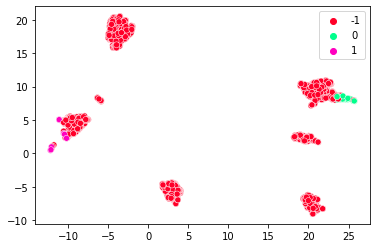

```python
sns.scatterplot(x=X_2d_umap[:,0],y=X_2d_umap[:,1], hue = preds, palette='gist_rainbow')
```

Most points are outliers. However it would be an interesting side project to examine the similiarities and differences between the clusters DBSCAN found.

### Clustering depression and demographic variables combined

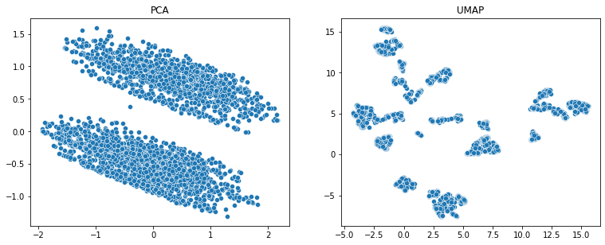

```python
pca=PCA(n_components=2)
X_2d_pca = pca.fit_transform(X)
umap = UMAP(n_components=2)
X_2d_umap = umap.fit_transform(X)
fig, axs = plt.subplots(1,2,figsize=(12.8,4.8))
sns.scatterplot(x=X_2d_pca[:,0],y=X_2d_pca[:,1], ax=axs[0])
axs[0].set_title('PCA')
sns.scatterplot(x=X_2d_umap[:,0],y=X_2d_umap[:,1], ax=axs[1])
axs[1].set_title('UMAP')
```

Both PCA and UMAP show clustering, with PCA showing 2 clusters and UMAP showing ten or more. Again nothing can be inferred because of loss of data.

#### KMeans

```
The elbow occurs at 13
```

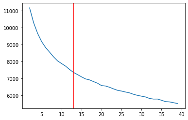

```python
inertia_values = []
for n in range(2,40):
    kmeans = KMeans(n_clusters=n, random_state=625+n)
    kmeans.fit(X)
    inertia_values.append((n,kmeans.inertia_))
results = list(zip(*inertia_values))
kl = KneeLocator(x=results[0],y=results[1],direction='decreasing',curve='convex')
elbow = kl.elbow
print('The elbow occurs at',elbow)

sns.lineplot(x=results[0],y=results[1])
plt.axvline(x=elbow, ymin=0, ymax = max(results[1]), color='red')
```

```python
kmeans = KMeans(n_clusters=13, random_state=625)
preds = kmeans.fit_predict(X)
score = silhouette_score(X,preds)
silhouette_scores['data set'].append('depression and demographics')
silhouette_scores['clustering method'].append('kmeans--auto-13')
silhouette_scores['score'].append(score)
print("The silhouette score for 13 clusters is {}".format(score))
```

```
The silhouette score for 13 clusters is 0.11342228036785383
```

The silhouette score is slightly less than that found just using the depression variables.

Looking at DBSCAN

#### DBSCAN

```python
db = DBSCAN(eps = 1.148, min_samples = 47)
preds = db.fit_predict(X)
print('The number of clusters selected by DBSCAN is {}'.format(preds.max()+1))
```

```
The number of clusters selected by DBSCAN is 3
```

```python
np.unique(preds, return_counts=True)
```

```
(array([-1,  0,  1,  2], dtype=int64),
 array([2714,  296,   60,   48], dtype=int64))
```

```python
print("The silhouette score for DBSCAN is {}".format(silhouette_score(X[preds!=-1],preds[preds!=-1])))
```

```
The silhouette score for DBSCAN is 0.28129897522030534
```

The silhouette score is much lower than when using DBSCAN with just the variables about depression and still the majority of observations are outliers. Again this is not good clustering.

### Clustering depression and chronic conditions

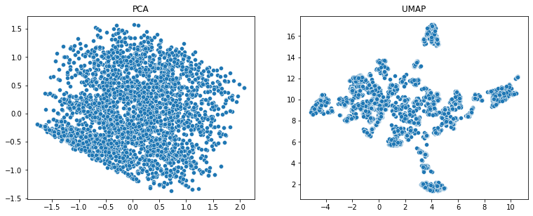

```python
pca=PCA(n_components=2)
X_2d_pca = pca.fit_transform(X)
umap = UMAP(n_components=2)
X_2d_umap = umap.fit_transform(X)
fig, axs = plt.subplots(1,2,figsize=(12.8,4.8))
sns.scatterplot(x=X_2d_pca[:,0],y=X_2d_pca[:,1], ax=axs[0])
axs[0].set_title('PCA')
sns.scatterplot(x=X_2d_umap[:,0],y=X_2d_umap[:,1], ax=axs[1])
axs[1].set_title('UMAP')
```

From umap there does appear to be some clustering in two dimensions but it is very close together.

#### Kmeans

```
The elbow occurs at 14
```

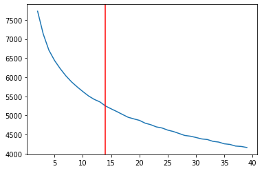

```python
inertia_values = []
for n in range(2,40):
    kmeans = KMeans(n_clusters=n, random_state=625+n)
    kmeans.fit(X)
    inertia_values.append((n,kmeans.inertia_))
results = list(zip(*inertia_values))
kl = KneeLocator(x=results[0],y=results[1],direction='decreasing',curve='convex')
elbow = kl.elbow
print('The elbow occurs at',elbow)

sns.lineplot(x=results[0],y=results[1])
plt.axvline(x=elbow, ymin=0, ymax = max(results[1]), color='red')
```

Again an elbow is not apparent. I'm guessing ahead of time that the silhouette score will again be lower for the combined dataset than the dataset with just depressed variables.

```python
kmeans = KMeans(n_clusters=14, random_state=625)
preds = kmeans.fit_predict(X)
score = silhouette_score(X,preds)
silhouette_scores['data set'].append('depression and demographics')
silhouette_scores['clustering method'].append('kmeans--auto-14')
silhouette_scores['score'].append(score)
print("The silhouette score for 14 clusters is {}".format(score))
```

```
The silhouette score for 14 clusters is 0.09369195200939438
```

The silhouette score is very small meaning clusters are mixing.

#### DBSCAN

```python
db = DBSCAN(eps = 0.8, min_samples = 55)
preds = db.fit_predict(X)
print('The number of clusters selected by DBSCAN is {}'.format(preds.max()+1))
```

```
The number of clusters selected by DBSCAN is 2
```

```python
np.unique(preds, return_counts=True)
```

```
(array([-1,  0,  1], dtype=int64), array([2933,  126,   59], dtype=int64))
```

```python
print("The silhouette score for DBSCAN is {}".format(silhouette_score(X[preds!=-1],preds[preds!=-1])))
```

```
The silhouette score for DBSCAN is 0.4510392979719503
```

The silhouette score is higher than the score found using dbscan with the depression and demographic data. Still there is too much noise.

Because Adding demographics and chronic_conditions only made the clustering perform worse, I am not going to combine all three as planned. As DBSCAN clustering found too many outliers, the clustering method I chose as best is kmeans on the depression data.

## Choice of clustering method

# Results

## Summary of clustereing methods

- DBSCAN did not perform well with any data subset as it predicted the vast majority of observations as outliers
- With the best silhouette score of approximately 0.17, kmeans mixes clusters.
- Kmeans with just the data with questions related to depression was chosen as the clustering method for this data.

### Visualizing the clustering

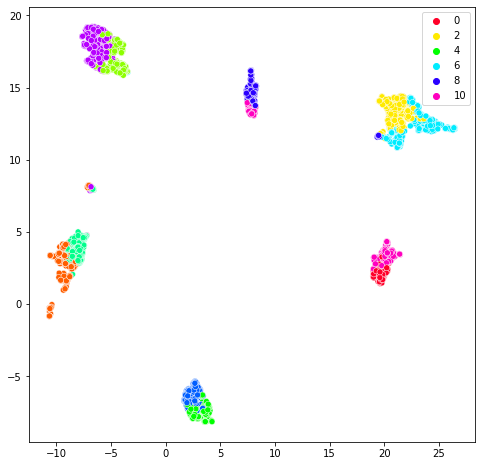

```python
plt.figure(figsize=(8, 8))
X_2d_umap = umap.fit_transform(X)
sns.scatterplot(x=X_2d_umap[:,0],y=X_2d_umap[:,1], hue = preds, palette='gist_rainbow')
```

As stated before, clusters appear mixed.

## Examining clusters

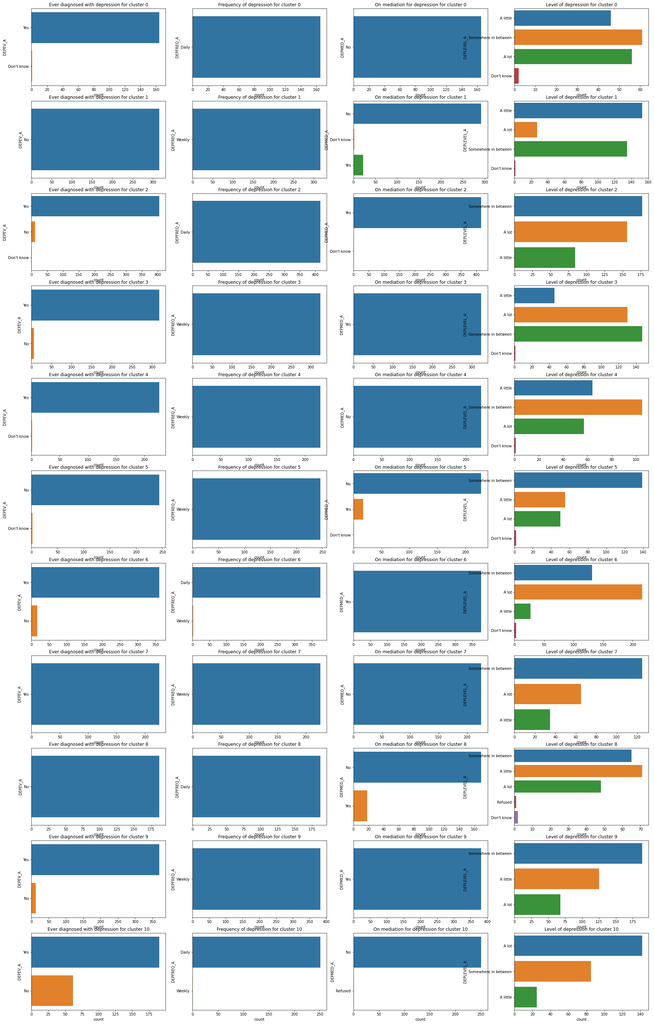

```python
fig, axs = plt.subplots(11,4, figsize=(30,50))
for i in range(11):
    cluster=df_depressed_core[df_depressed_core.cluster==i]
    sns.countplot(y='DEPEV_A',data=cluster,ax=axs[i,0])
    axs[i,0].set_title('Ever diagnosed with depression for cluster {}'.format(i))
    sns.countplot(y='DEPFREQ_A',data=cluster,ax=axs[i,1])
    axs[i,1].set_title('Frequency of depression for cluster {}'.format(i))
    sns.countplot(y='DEPMED_A',data=cluster,ax=axs[i,2])
    axs[i,2].set_title('On mediation for depression for cluster {}'.format(i))
    sns.countplot(y='DEPLEVEL_A',data=cluster,ax=axs[i,3])
    axs[i,3].set_title('Level of depression for cluster {}'.format(i))
```

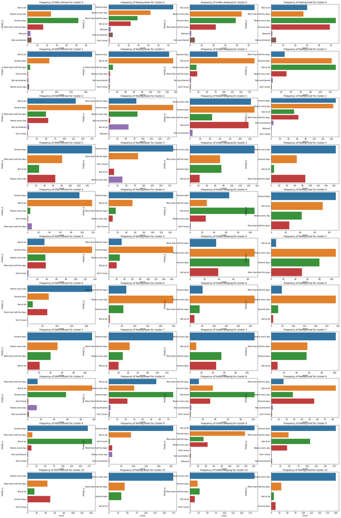

```python
fig, axs = plt.subplots(11,4, figsize=(30,50))
for i in range(11):
    cluster=df_depressed_core[df_depressed_core.cluster==i]
    sns.countplot(y='PHQ81_A',data=cluster,ax=axs[i,0])
    axs[i,0].set_title('Frequency of little interest for cluster {}'.format(i))
    sns.countplot(y='PHQ82_A',data=cluster,ax=axs[i,1])
    axs[i,1].set_title('Frequency of feeling down for cluster {}'.format(i))
    sns.countplot(y='PHQ83_A',data=cluster,ax=axs[i,2])
    axs[i,2].set_title('Frequency of troble sleeping for cluster {}'.format(i))
    sns.countplot(y='PHQ84_A',data=cluster,ax=axs[i,3])
    axs[i,3].set_title('Frequency of feeling tired for cluster {}'.format(i))
```

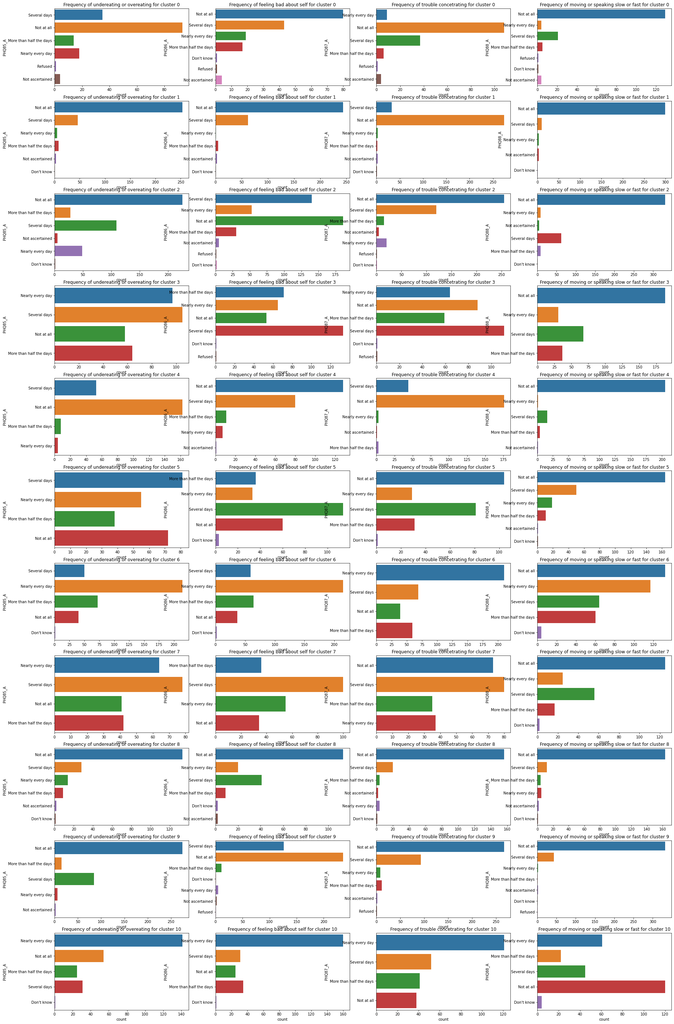

```python
fig, axs = plt.subplots(11,4, figsize=(30,50))
for i in range(11):
    cluster=df_depressed_core[df_depressed_core.cluster==i]
    sns.countplot(y='PHQ85_A',data=cluster,ax=axs[i,0])
    axs[i,0].set_title('Frequency of undereating or overeating for cluster {}'.format(i))
    sns.countplot(y='PHQ86_A',data=cluster,ax=axs[i,1])
    axs[i,1].set_title('Frequency of feeling bad about self for cluster {}'.format(i))
    sns.countplot(y='PHQ87_A',data=cluster,ax=axs[i,2])
    axs[i,2].set_title('Frequency of trouble concetrating for cluster {}'.format(i))
    sns.countplot(y='PHQ88_A',data=cluster,ax=axs[i,3])
    axs[i,3].set_title('Frequency of moving or speaking slow or fast for cluster {}'.format(i))
```

## Summary of clusters

- Cluster 0 - All feel depressed daily and are not on medication for depression. The vast majority have been diagnosed with depression. Although it varies, the only symptom the majority of cluster 0 feels is feeling tired.
- Cluster 1 - All feel depressed weekly and have not been diagnosed with depression. With the exception of a little less than half feeling down several days, most have no symptoms.
- Cluster 2 - All feel depressed daily and the vast majority are on medication for depression. With the exception of under or over eating, trouble concentrating, or moving and talking fast or slow, cluster 2 feels most other symptoms at least several days in the past two weeks.
- Cluster 3 - All feel depressed weekly and are on medication for depression. With the exception of moving or talking fast or slow, symptoms are felt several days or nearly every day for most.
- Cluster 4 - All feel depressed weekly and are not on medication for depression. The vast majority have been diagnosed with depression.
- Cluster 5 - All feel depressed weekly, the vast majority have not been diagnosed with depression. The majority have lack of interest, feeling down, trouble sleeping and feeling tired at least several days in the past two weeks.
- Cluster 6 - All are on medication for depression. With the exception of slow or fast speech or movement, other symptoms are felt nearly every day for the vast majority.
- Cluster 7 - All have been diagnosed with depression, feel depression weekly and are not on medication. With the of slow or fast speech or movement, symptoms are felt several days or nearly every day for most.
- Cluster 8 - All feel depression daily but have not been diagnosed with depression. With the exception of feeling down, all other symptoms are not felt for most.
- Cluster 9 - All feel depression weekly and are on medication for depression. Most have no symptoms of over or undereating, feeling sad about themselves, trouble concentrating or slow or fast movement.
- Cluster 10 - The vast majority are not on medication for depression. With the exception of slow or fast speech or movement most feel every other symptom nearly every day.

# Discussion and Recommendations

- Given cluster mixing it was difficult to interpret clusters with respect to symptoms. For some clusters it was divided, for exammple, between a certain symptom not felt at all or being felt several days.
- Seperation of clusters was more apparent with respect to being diagnosed with depression, the frequency of feeling depressed, and wether or not the individual was on medication for depression.
- As this was not a survey about depression, to better cluster groups for analysis I would suggest creating a survey targeted for those suffering from depression. Then examining of clusters could suggest better therapies and treatments. For example this data did not contain any information on the type or dosage of medication or if any therapy was being received. The analysis I performed can be used as a starting point for the new survey.

### Further items to explore with this data set in the future

- As many have been diagnosed with depression and are not on medication it would be interesting to look at their medical coverage. Maybe some have no medical coverage and so cannot afford medication for depression. The same goes for those feeling depressed and not diagnosed with depression. Have they not seen a doctor due to medical coverage?
- Because of mixing of clusters an examination of clustering using Gaussian mixture models would be interesting.
- As more women suffer from depression than men, it would be interesting to see if silhouette score improves by just adding sex.

# References

1. National Institute of Mental Health. Major Depression. https://www.nimh.nih.gov/health/statistics/major-depression
2. InformedHealth.org [Internet]. Cologne, Germany: Institute for Quality and Efficiency in Health Care (IQWiG); 2006-. Depression: How effective are antidepressants? [Updated 2020 Jun 18]. Available from: https://www.ncbi.nlm.nih.gov/books/NBK361016/
3. National Center for Health Statistics. (April 5, 2021) National Health Interview Survey. https://www.cdc.gov/nchs/nhis/2019nhis.htm
4. National Center for Health Statistics. (September 16, 2020). About the National Health Interview Survey. https://www.cdc.gov/nchs/nhis/about_nhis.htm
5. American Psychiatric Association. (October, 2020). What is depression? https://www.psychiatry.org/patients-families/depression/what-is-depression
6. Sharma, A. (2020, September 8) How to Master the Popular DBSCAN Clustering Algorithm for Machine Learning. Analytics Vidhya. https://www.analyticsvidhya.com/blog/2020/09/how-dbscan-clustering-works/
7. Mullin, T. (2020, July 9) DBSCAN Parameter Estimation Using Python. Medium. https://medium.com/@tarammullin/dbscan-parameter-estimation-ff8330e3a3bd
8. Erich Schubert, Jörg Sander, Martin Ester, Hans-Peter Kriegel, and Xiaowei Xu. 2017. DBSCAN Revisited, Revisited: Why and How You Should (Still) Use DBSCAN. ACM Trans. Database Syst. 42, 3, Article 19 (July 2017), 21 pages. https://doi.org/10.1145/3068335

# Appendix

## Exploratory data analysis

### Depression variables

```python
df_depressed_core.head()
```

|  | DEPEV_A | DEPFREQ_A | DEPMED_A | DEPLEVEL_A | PHQ81_A | PHQ82_A | PHQ83_A | PHQ84_A | PHQ85_A | PHQ86_A | PHQ87_A | PHQ88_A | cluster |
| --- | --- | --- | --- | --- | --- | --- | --- | --- | --- | --- | --- | --- | --- |
| 4 | Yes | Daily | Yes | Somewhere in between | Nearly every day | More than half the days | Several days | More than half the days | Several days | Several days | Nearly every day | Not at all | 6 |
| 28 | No | Weekly | No | Somewhere in between | Not at all | More than half the days | More than half the days | Not at all | Several days | More than half the days | Not at all | Not at all | 5 |
| 37 | Yes | Daily | Yes | Somewhere in between | Not at all | More than half the days | Nearly every day | Several days | Not at all | Several days | Not at all | Not at all | 2 |
| 41 | No | Weekly | No | Somewhere in between | Several days | More than half the days | Nearly every day | Nearly every day | Nearly every day | Nearly every day | Nearly every day | Not at all | 5 |
| 48 | Yes | Daily | No | A little | Not at all | Several days | Not at all | Not at all | Several days | Not at all | Nearly every day | Not at all | 0 |

#### DEPEV_A

According to the codebook, DEPEV_A is the response to the question: "Have you ever been told by a doctor or health professional that you had ...any type of depression?"

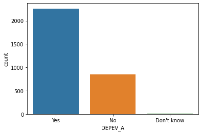

```python
sns.countplot(x='DEPEV_A',data=df_depressed_core)
```

The majority that feel depression on a weekly or daily basis have been told by a doctor they do have depression.

#### DEPFREQ_A

DEPFREQ_A is the response to the question, "how often do you feel depressed?"

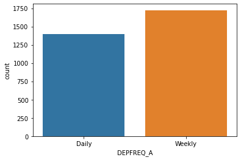

```python
sns.countplot(x='DEPFREQ_A', data=df_depressed_core)
```

As seen above, a little more than half of the people feel depressed on a weekly basis.

#### DEPMED_A

DEPMED_A represents responces to the question, "Do you take prescription medication for depression?"

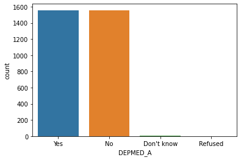

```python
sns.countplot(x='DEPMED_A',data=df_depressed_core)
```

Approximately half of the respondents do take medication. It would be intererested to explore the relationship between levels of depression and DEPMED_A as well as exploring medical insurance variables for those whom do not take medication.

#### DEPLEVEL_A

DEPLEVEL_A is the respondent's answer to the question, "Thinking about the last time you felt depressed, how depressed did you feel? Would you say a little, a lot, or somewhere in between?"

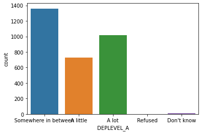

```python
sns.countplot(x='DEPLEVEL_A', data=df_depressed_core)
```

Most people feeling depressed on a daily or weekly basis said they feel somewhere in between a little and a lot depressed.

#### PHQ81_A through PHQ88_A

These questions ask how often they are bothered by certain symptoms of depression within the last two weeks.

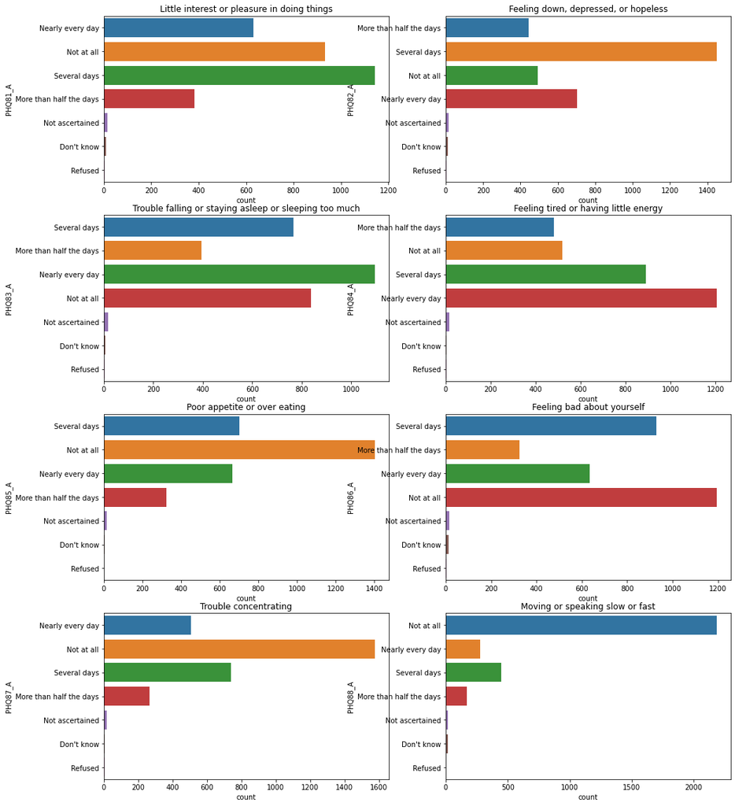

```python
fig, axs = plt.subplots(4,2, figsize=(16,20))
sns.countplot(y='PHQ81_A',data=df_depressed_core,ax=axs[0,0])
axs[0,0].set_title('Little interest or pleasure in doing things')
sns.countplot(y='PHQ82_A',data=df_depressed_core,ax=axs[0,1])
axs[0,1].set_title('Feeling down, depressed, or hopeless')
sns.countplot(y='PHQ83_A',data=df_depressed_core,ax=axs[1,0])
axs[1,0].set_title('Trouble falling or staying asleep or sleeping too much')
sns.countplot(y='PHQ84_A',data=df_depressed_core,ax=axs[1,1])
axs[1,1].set_title('Feeling tired or having little energy')
sns.countplot(y='PHQ85_A',data=df_depressed_core,ax=axs[2,0])
axs[2,0].set_title('Poor appetite or over eating')
sns.countplot(y='PHQ86_A',data=df_depressed_core,ax=axs[2,1])
axs[2,1].set_title('Feeling bad about yourself')
sns.countplot(y='PHQ87_A',data=df_depressed_core,ax=axs[3,0])
axs[3,0].set_title('Trouble concentrating')
sns.countplot(y='PHQ88_A',data=df_depressed_core,ax=axs[3,1])
axs[3,1].set_title('Moving or speaking slow or fast')
```

As you can see the most common frequency of the symptoms vary from not at all to nearly every day.

### Demographic information

```python
df_demo.head()
```

|  | AGEP_A | SEX_A | MARITAL_A | FAMINCTC_A | EDUC_A | EMPWRKLSWK_A | RACEALLP_A | HISP_A |
| --- | --- | --- | --- | --- | --- | --- | --- | --- |
| 4 | 60 | Male | Married | 30000 | Some college, no degree | Yes | White only | No |
| 28 | 26 | Male | Married | 60000 | Grade 8 - 11 | No | Black/African American only | No |
| 37 | 60 | Female | Neither | 52877 | Some college, no degree | No | White only | No |
| 41 | 24 | Female | Unmarried, living with partner | 20000 | Some college, no degree | Yes | American indian and other | No |
| 48 | 53 | Female | Neither | 9000 | Some college, no degree | No | White only | Yes |

#### AGEP_A

AGEP_A holds the age of the adult.

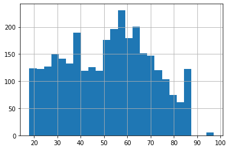

```python
df_demo.AGEP_A.hist(bins=25)
```

All age groups are represented with some peaks around or before 40, between 50 and 60, and around 85. Those between 50 and 60 may be depressed because they are facing a mid life crisis. For women, maybe menapause cases depression?

#### SEX_A

SEX_A states the sex of the adult

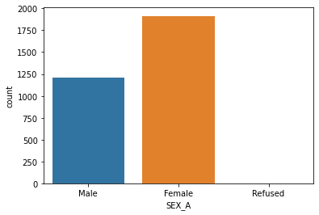

```python
sns.countplot(x='SEX_A', data=df_demo)
```

More women feel depressed on a weekly or daily basis then men.

#### MARITAL_A

MARITAL_A states the marital status

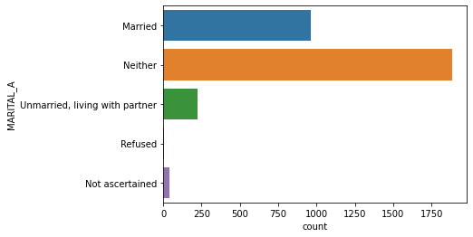

```python
sns.countplot(y='MARITAL_A',data=df_demo)
```

The majority of those that feel depressed on a daily or weekly basis are neither married no living with a partner.

#### FAMINCTC_A

FAMINCTC_A lists the family income of the individual

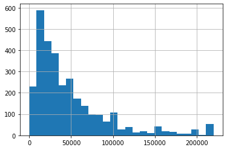

```python
df_demo.FAMINCTC_A.hist(bins=25)
```

#### EDUC_A

EDUC_A lists the education level of the individual.

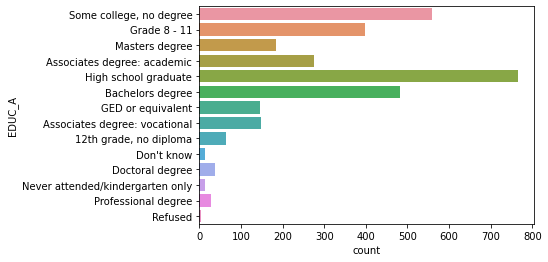

```python
sns.countplot(y='EDUC_A',data=df_demo)
```

The majprity of those that feel depressed on a daily or weekly basis are high school graduates. There are many levels with very few counts. When preparing data I may want to combine some such as the associates degrees and the professional and masters degrees.

#### EMPWRKLSWK_A

EMPWRKLSWK_A denotes if the individual worked last week.

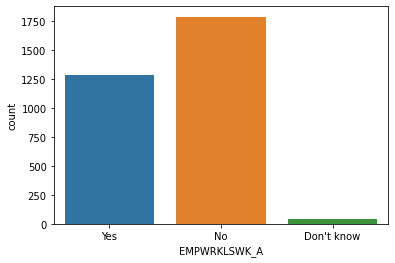

```python
sns.countplot(x='EMPWRKLSWK_A',data=df_demo)
```

The majority of those whom fell depressed dd not work. This poses the question did the depression stop them from working or are they depressed due to unemployment?

#### RACEALLP_A

RACEALLP_A covers the race of the adult

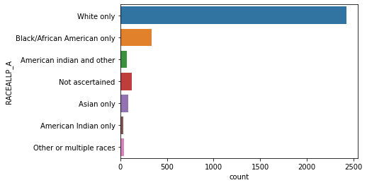

```python
sns.countplot(y='RACEALLP_A', data=df_demo)
```

The majority are white only, however the majority of respondents were white.

#### HISP_A

HISP_A states wether or not the adult is of Hispanic ethnicity.

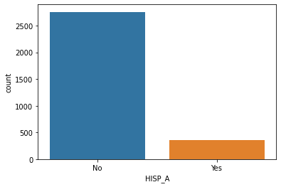

```python
sns.countplot(x='HISP_A',data=df_demo)
```

The majority are not of Hispanic ethnicity, but then again the majority of the respondants were not Hispanic.

### Chronic conditions

The variables address the following questions

- HYPEV_A -- Have you ever been told you have hypertension?
- CHLEV_A -- Have you ever been told you have high cholesterol?
- ASEV_A -- Have you ever been told you have asthma?
- CANEV_A -- Have you ever been told you have cancer?
- DIBEV_A -- Have you ever been told you have diabetes?
- COPDEV_A -- Have you ever been told you have COPD, chronic bronchitis or emphysema?

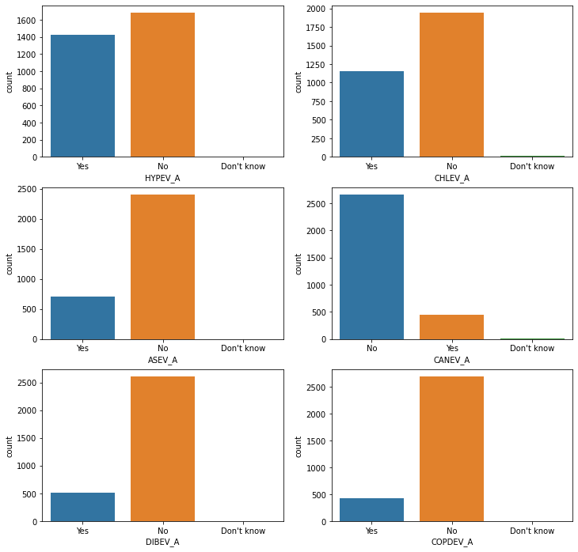

```python
fig, axs = plt.subplots(3,2, figsize = (12,12))
sns.countplot(x='HYPEV_A', data = df_cc, ax=axs[0,0])
sns.countplot(x='CHLEV_A', data = df_cc, ax=axs[0,1])
sns.countplot(x='ASEV_A', data = df_cc, ax=axs[1,0])
sns.countplot(x='CANEV_A', data = df_cc, ax=axs[1,1])
sns.countplot(x='DIBEV_A', data = df_cc, ax=axs[2,0])
sns.countplot(x='COPDEV_A', data = df_cc, ax=axs[2,1])
```

## Why not one-hot encode the depression variables?

With clustering you are interested in distances, or differences. When given values that have a natural order you do not want to one hot encode them. For example, say everything else was held constant except for how often a person feels fatigued. Looking at three observations, one person feels fatigued nearly every day, another person feels fatigue not at all, and another person feels fatigued several days. If fatigue frequency was one hot encoded, then the distance between the person the feels fatigued every day and the person feeling fatigued several days will be the same as the distance between the person that feels fatigued every day and the person that does not feel fatigued at all if using Euclidean or Manhattan distance. When in fact the latter is much more different than the former.

## Links

Anne Losch on LinkedIn. https://www.linkedin.com/in/annelosch/